# Assignmnet5_quant

Sage Grey

9/27/2020

## *Overview of Assignment & Bird’s Eye Summary of Results*

The intention of Assignment 5 is to experiment with alternate ways to fit a model. The syllabus mentions using this assignment to explore which model best explains our model fit. Generally I discovered that adding interaction terms slightly improved the model fit.

I personally was really interested in how the model worked when predicting various ways to measure income. Specifically Personal Income (PINCP), Household Income (HINCP), and Household Income per Person in Household (HINCP/NP).

In my regressions I used Number of People in Household, Individual’s Age, and whether or not they lived in a single-family home to look at income. For all the regressions, I created a variation where whether or not the individual lived in a single-family home was set as an interaction term.

Also included in this document are experiments with a single-term model and a logistic regression.

#### **Notes on Changes to Dataset**

For this assignment, I wanted to filter my Dataset to get closer at my area of interest –> Development in Bernallilo County.

Also for the sake of learning more about logistic regressions and best fit, I have decided to compress building type into a binary variable of “Single-Family Home” and “Not a single family home.”

I’m holding changes made in my last assignment constant which were: 1. Combining Race and Ethnicity (although updated slightly). 2. Combining apartment types into condensed categories. 3. Binning Construction Dates into 20 year intervals

## *House Keeping*

#### Loading Libraries

```r
library(tidyverse)
library(tidycensus)
library(ggplot2)
library(ggthemes)
library(plyr)
library(epiDisplay)
library(dplyr)
library(gridExtra)
library(tidyverse)
library(jtools)
library(interactions)
library(knitr)
```

#### **Code written in separate file (trying to limit the Data Consumption of R)**

> New_Mexico_Vars_Development <- get_pums(variables = c(“YBL”, “HINCP”, “RAC1P”, “JWMNP”, “NP”, “PUMA”, “HISP”, “AGEP”, “BLD”, “PINCP”), state= “NM”, year =2018, survey =“acs1”, recode=TRUE) %>% mutate(PUMA = as.numeric(PUMA))%>% filter(PUMA> 00100 & PUMA <01200)%>% filter(HINCP >0)%>%

> dplyr::select(HINCP, RAC1P, JWMNP, NP, PUMA, HISP, AGEP, BLD, PINCP)

> write_csv(New_Mexico_Vars_Development, “New_Mexico_Vars_Development”)

##### **Load Household Data Set & Shortening Vars**

```r
#Load DataSet from CSV

assignment4_vars <- read_csv("New_Mexico_Vars_Development")
assignment5_vars <- read_csv("New_Mexico_Vars_Development")


assignment5_vars <-assignment5_vars %>%

 #Filter for Only Bernallilo COunty
  filter(PUMA == 00700|
         PUMA == 00801|
         PUMA == 00802|
         PUMA == 00803|
         PUMA == 00804|
         PUMA == 00805|
         PUMA == 00806) %>%





#Mutate Building Type
  mutate(bld_type =case_when(
                        BLD_label == "One-family house detached" ~ "fam_home",
                        BLD_label == "One-family house attached" ~ "fam_home",
                        BLD_label == "2 Apartments" ~ "not_1_fam_home",
                        BLD_label == "Mobile home or trailer" ~ "not_1_fam_home",
                        BLD_label == "3-4 Apartments" ~ "not_1_fam_home",
                        BLD_label == "5-9 Apartments" ~ "not_1_fam_home",
                        BLD_label == "10-19 Apartments" ~ "not_1_fam_home",
                        BLD_label == "20-49 Apartments" ~ "not_1_fam_home",
                        BLD_label == "50 or more apartments" ~ "not_1_fam_home",
                        BLD_label == "Boat, RV, van, etc." ~"not_1_fam_home",
                        TRUE ~ "Other" )) %>%

#Mutate YBL to Decade House Was Built
  mutate(when_built = case_when(
                        YBL_label == "1939 or earlier" ~ "1 pre 1940",
                        YBL_label == "1940 to 1949" ~ "1.2 40s/50s",
                        YBL_label == "1950 to 1959" ~ "1.2 40s/50s",
                        YBL_label == "1960 to 1969" ~ "1.3 60s/70s",
                        YBL_label == "1970 to 1979" ~ "1.3 60s/70s",
                        YBL_label == "1980 to 1989" ~ "1.4 80s/90s",
                        YBL_label == "1990 to 1999" ~ "1.4 80s/90s",
                        YBL_label == "2000 to 2004" ~ "2000s/10s",
                        YBL_label == "2005"~ "2000s/10s" ,
                        YBL_label == "2006"~ "2000s/10s" ,
                        YBL_label == "2007"~ "2000s/10s" ,
                        YBL_label == "2008"~ "2000s/10s",
                        YBL_label == "2009" ~ "2000s/10s",
                               YBL_label == "2010" ~ "2000s/10s",
                               YBL_label == "2011" ~ "2000s/10s",
                               YBL_label == "2012" ~ "2000s/10s",
                               YBL_label == "2013" ~ "2000s/10s",
                               YBL_label == "2014" ~ "2000s/10s",
                               YBL_label == "2015" ~ "2000s/10s",
                               YBL_label == "2016" ~ "2000s/10s",
                               YBL_label == "2017" ~ "2000s/10s",
                               YBL_label == "2018" ~ "2000s/10s",
                        TRUE ~"Other")) %>%

#Recode Journey to Work as a Categorical Variable
mutate(JWMNP_binned = case_when(
          JWMNP <15 ~ "Less Than 15 minutes",
          JWMNP <30 & JWMNP >15 | JWMNP == 15 ~ "15 - 30 minutes",
          JWMNP >30 & JWMNP <45 | JWMNP == 45 ~ "30 - 45 minutes",
          JWMNP >45 & JWMNP <60 | JWMNP == 60 ~ "45 - 60 minutes",
          JWMNP >60 & JWMNP <75 | JWMNP == 75 ~ "60 - 75 minutes",
          TRUE ~ "No Commute Reported")) %>%

#Recode Race & Ethnicity Together
  mutate(race_ethn = case_when(

    #WHITE
   RAC1P == "1" & HISP == "1" ~ "1 White (NH)",
   RAC1P == "1" & HISP != "1" ~ "White (Hisp)",

   #NATIVE AMERICAN (inc Alaska Native)

   RAC1P == "3" & HISP == "1" ~ "Native American (NH)",
   RAC1P == "3" & HISP != "1" ~"Native American (Hisp)",

   RAC1P == "7" & HISP == "1" ~ "Native American (NH)",
   RAC1P == "7" & HISP != "1"~ "Native American (Hisp)",

   RAC1P == "9" & HISP == "1" ~ "Native American (NH)",
   RAC1P == "9" & HISP != "1" ~"Native American (Hisp)",

   #AFRICAN AMERICAN / BLACK
    RAC1P == "4" & HISP == "1" ~ "Black/AA",
    RAC1P == "4" & HISP != "1" ~ "Black/AA",

   #ASIAN
   RAC1P =="6" & HISP == "1" ~ "Asian",
   RAC1P =="6" & HISP != "1" ~ "Asian",

   #SOME OTHER RACE ALONE & MULTIRACIAL

   RAC1P == "2" & HISP == "1" ~ "Other Race or Multiracial (NH)",
   RAC1P == "2" & HISP != "1"~ "Other (Hisp)",

   RAC1P == "5" & HISP == "1" ~ "Other Race or Multiracial (NH)",
   RAC1P == "5" & HISP != "1"~ "Other (Hisp)",

   #Native Hawaiian, Pacific Islander --> Coded as Other Race
   RAC1P == "8" & HISP == "1" ~ "Other Race or Multiracial (NH)",
   RAC1P == "8" & HISP != "1" ~ "Other (Hisp)",

   # Other
   TRUE ~ "Other"))%>%




dplyr::select(HINCP, race_ethn, RAC1P_label, HISP_label, JWMNP_binned, NP, PUMA, when_built, AGEP, bld_type, PINCP, BLD_label)
```

**Discussion of Race/Ethn Decisions** Main Takeaway: Ooof.

Decided that for Bernallilo County (and trying to base this off the exploration of data I’ve done in last few assignments, not my personal experience in abq) I decided to break the following categories down in the following ways:

Hispanic & Non-Hispanic Lumped:  
Asian  
Black/AA

A large assumption that I am making is that for individuals identifying as Asian or Black their racial identity is more important than their ethnic identity (Hispanic/Non-Hispanic). I am deciding to collapse these categories since there are such small number of Asian and Black observations in the data set.

## *Exploring DataSet*

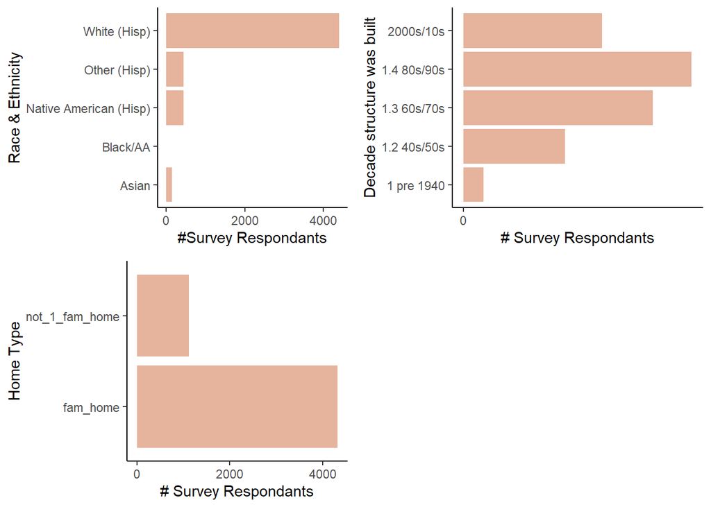

```r
# 4 figures arranged in 2 rows and 2 columns

#Explore Race and Ethnicity Variables

r_e <- ggplot(assignment5_vars, aes(x = race_ethn)) +
  geom_bar(fill="sienna3", alpha=.5) +
   theme(axis.text.x = element_text(angle = 90)) +
   scale_x_discrete(name="Race & Ethnicity") +
    scale_y_continuous(name= "#Survey Respondants",
                       breaks = seq(0,8000, by = 2000),
                     labels = paste(seq(0,8000, by = 2000),
                     "", sep = "")) +
  coord_flip()+
  theme_classic()



#Explore Building Type

bld <- ggplot(assignment5_vars, aes(x =bld_type)) +
  geom_bar(fill="sienna3", alpha =.5) +
   theme(axis.text.x = element_text(angle = 90)) +
   scale_x_discrete(name="Home Type") +
    scale_y_continuous(name= "# Survey Respondants",
                       breaks = seq(0,8000, by = 2000),
                     labels = paste(seq(0,8000, by = 2000),
                     "", sep = "")) +
  coord_flip() +
  theme_classic()




# Explore Decade Home Was Built
dev <- ggplot(assignment5_vars, aes(x = when_built)) +
  geom_bar(fill= "sienna3", alpha=.5) +
   theme(axis.text.x = element_text(angle = 90)) +
  scale_x_discrete(name="Decade structure was built") +
    scale_y_continuous(name= "# Survey Respondants",
                       breaks = seq(0,8000, by = 2000),
                     labels = paste(seq(0,8000, by = 2000),
                     "", sep = "")) +
  coord_flip() +
  theme_classic()

# Plot Together

grid.arrange(r_e,dev, bld, ncol=2, nrow=2)
```

## **MOD1:** What happens with one-term models?

Conceptual question, what is the difference between a correlation and a one-variable model. If the R-Squared tells us the amount of variability of dependent that can be explained by the independent, shouldn’t this be similar to their correlation?

Will this be the same as Pearson’s Correlation?

```r
correlation_HINCP_AGEP <- cor.test(assignment5_vars$HINCP, assignment5_vars$AGEP)

correlation_HINCP_AGEP
```

```
##
##  Pearson's product-moment correlation
##
## data:  assignment5_vars$HINCP and assignment5_vars$AGEP
## t = 0.60675, df = 5434, p-value = 0.544
## alternative hypothesis: true correlation is not equal to 0
## 95 percent confidence interval:
##  -0.01835768  0.03480740
## sample estimates:
##         cor
## 0.008230675
```

```r
model_4 <- lm(HINCP ~ AGEP , data =assignment5_vars)
summary(model_4)
```

```
##
## Call:
## lm(formula = HINCP ~ AGEP, data = assignment5_vars)
##
## Residuals:
##    Min     1Q Median     3Q    Max
## -88272 -53802 -22344  21965 696594
##
## Coefficients:
##             Estimate Std. Error t value Pr(>|t|)
## (Intercept) 87042.93    2462.55  35.347   <2e-16 ***
## AGEP           30.22      49.81   0.607    0.544
## ---
## Signif. codes:  0 '***' 0.001 '**' 0.01 '*' 0.05 '.' 0.1 ' ' 1
##
## Residual standard error: 87050 on 5434 degrees of freedom
## Multiple R-squared:  6.774e-05,  Adjusted R-squared:  -0.0001163
## F-statistic: 0.3681 on 1 and 5434 DF,  p-value: 0.544
```

Answer: Yes! They match. The Pearson’s Correlation is not significant,and neither is the model!

## **MOD2:** Predicting Personal Income

### Predicting Personal Income: Baseline Model (No Interactions)

```r
model_2 <- lm(PINCP ~ bld_type + NP + AGEP , data =assignment5_vars)
summary(model_2)
```

```
##
## Call:
## lm(formula = PINCP ~ bld_type + NP + AGEP, data = assignment5_vars)
##
## Residuals:
##    Min     1Q Median     3Q    Max
## -71251 -26103 -10994  10605 662995
##
## Coefficients:
##                         Estimate Std. Error t value Pr(>|t|)
## (Intercept)             13199.64    2656.10   4.970 6.92e-07 ***
## bld_typenot_1_fam_home -12869.80    1764.73  -7.293 3.47e-13 ***
## NP                      -3327.44     480.20  -6.929 4.72e-12 ***
## AGEP                      721.59      33.56  21.504  < 2e-16 ***
## ---
## Signif. codes:  0 '***' 0.001 '**' 0.01 '*' 0.05 '.' 0.1 ' ' 1
##
## Residual standard error: 51820 on 5432 degrees of freedom
## Multiple R-squared:  0.1434, Adjusted R-squared:  0.1429
## F-statistic: 303.2 on 3 and 5432 DF,  p-value: < 2.2e-16
```

### Predicting Personal Income: Interaction Terms

```r
model_2.1 <- lm(PINCP ~ bld_type + NP + AGEP + NP:bld_type + AGEP:bld_type, data =assignment5_vars)
summary(model_2.1)
```

```
##
## Call:
## lm(formula = PINCP ~ bld_type + NP + AGEP + NP:bld_type + AGEP:bld_type,
##     data = assignment5_vars)
##
## Residuals:
##    Min     1Q Median     3Q    Max
## -73400 -25068 -11487  10100 662081
##
## Coefficients:
##                             Estimate Std. Error t value Pr(>|t|)
## (Intercept)                 10445.34    2942.85   3.549 0.000389 ***
## bld_typenot_1_fam_home        717.60    5989.85   0.120 0.904643
## NP                          -3235.69     544.31  -5.945 2.94e-09 ***
## AGEP                          776.91      37.24  20.862  < 2e-16 ***
## bld_typenot_1_fam_home:NP    -737.51    1155.53  -0.638 0.523341
## bld_typenot_1_fam_home:AGEP  -291.74      85.51  -3.412 0.000650 ***
## ---
## Signif. codes:  0 '***' 0.001 '**' 0.01 '*' 0.05 '.' 0.1 ' ' 1
##
## Residual standard error: 51760 on 5430 degrees of freedom
## Multiple R-squared:  0.1455, Adjusted R-squared:  0.1447
## F-statistic: 184.9 on 5 and 5430 DF,  p-value: < 2.2e-16
```

### Which is the better fit?

```r
coeff_names <- c( "Age of Person" = "AGEP",
                 "Number Of People in House" = "NP",
                 "Single Family \n Compared to Not Single Family" = "bld_typenot_1_fam_home",
                 "Interaction:\n Not Single Family Home and Age" = "bld_typenot_1_fam_home:AGEP",
                 "Interaction: \n Not Single Family Home and Number Of People in House" = "bld_typenot_1_fam_home:NP")


export_summs(model_2, model_2.1,
             error_format = "(p = {p.value})",
             error_pos = "same",
             model.names = c("Baseline model", "Interaction Terms"),
             coefs = coeff_names)
```

|  | Baseline model | Interaction Terms |
| --- | --- | --- |
| Age of Person | 721.59 *** (p = 0.00) | 776.91 *** (p = 0.00) |
| Number Of People in House | -3327.44 *** (p = 0.00) | -3235.69 *** (p = 0.00) |
| Single Family Compared to Not Single Family | -12869.80 *** (p = 0.00) | 717.60 (p = 0.90) |
| Interaction: Not Single Family Home and Age |  | -291.74 *** (p = 0.00) |
| Interaction: Not Single Family Home and Number Of People in House |  | -737.51 (p = 0.52) |
| N | 5436 | 5436 |
| R2 | 0.14 | 0.15 |
| *** p < 0.001; ** p < 0.01; * p < 0.05. |  |  |

Regression with interactions is a better fitting model!

### Plot Coef

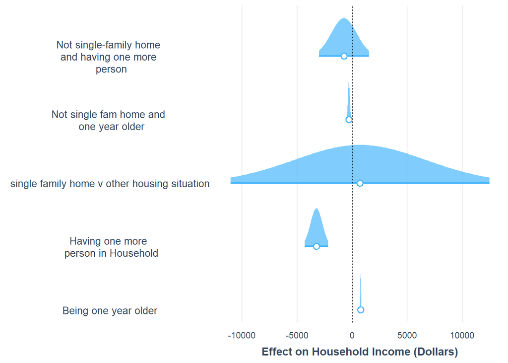

```r
coeff_interact <- c( "Being one year older" = "AGEP",
                 "Having one more \n person in Household" = "NP",
                 "single family home v other housing situation" = "bld_typenot_1_fam_home",
                 "Not single fam home and \n one year older" = "bld_typenot_1_fam_home:AGEP",
                 "Not single-family home \nand having one more \n person" = "bld_typenot_1_fam_home:NP")

plot_coefs(model_2.1,
           coefs = coeff_interact,
           plot.distributions = TRUE,
           rescale.distributions = TRUE) +
  scale_x_continuous(name = "Effect on Household Income (Dollars)")
```

### Plot Model

```
## Warning: Removed 41 row(s) containing missing values (geom_path).
```

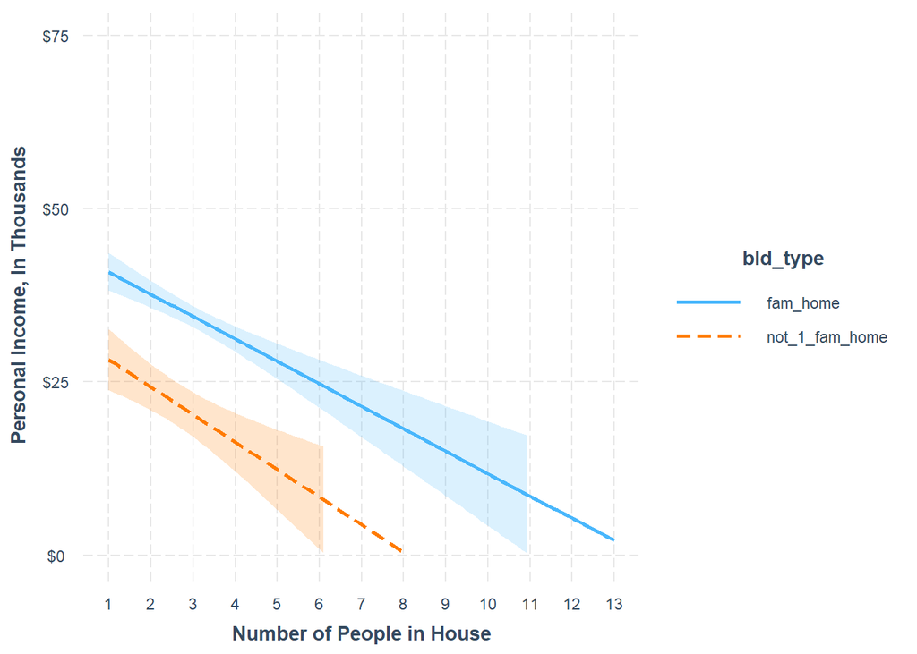

```r
model_2.1_plot <- interact_plot(model_2.1, pred = NP, modx = bld_type, interval = TRUE) +

  scale_y_continuous(name = "Personal Income, In Thousands",
                     limits = c(0, 75000),
                     breaks = breaks <- seq(0, 750000, by = 25000),
                     labels = paste("$",
                                    prettyNum(breaks/1000, big.mark = "'"),
                                    sep = "")) +
  scale_x_continuous(name = "Number of People in House",
                     breaks = seq(0, 13, by = 1))

model_2.1_plot
```

**Question for Grader**: Is it important that it is warning me that it removed 41 rows? what does this mean?

## **MOD3:** Household Income

### Predicting Household Income: Baseline Model (No Interactions)

```r
model_3 <- lm(HINCP ~ bld_type + NP + AGEP, data =assignment5_vars)
summary(model_3)
```

```
##
## Call:
## lm(formula = HINCP ~ bld_type + NP + AGEP, data = assignment5_vars)
##
## Residuals:
##     Min      1Q  Median      3Q     Max
## -128464  -48848  -17948   19280  693165
##
## Coefficients:
##                         Estimate Std. Error t value Pr(>|t|)
## (Intercept)             58117.85    4260.98   13.64  < 2e-16 ***
## bld_typenot_1_fam_home -48545.30    2831.02  -17.15  < 2e-16 ***
## NP                       9862.29     770.34   12.80  < 2e-16 ***
## AGEP                      245.49      53.83    4.56 5.22e-06 ***
## ---
## Signif. codes:  0 '***' 0.001 '**' 0.01 '*' 0.05 '.' 0.1 ' ' 1
##
## Residual standard error: 83120 on 5432 degrees of freedom
## Multiple R-squared:  0.0886, Adjusted R-squared:  0.08809
## F-statistic:   176 on 3 and 5432 DF,  p-value: < 2.2e-16
```

### Predicting Household Income: Interaction Terms

```r
model_3.1 <- lm(HINCP ~ bld_type + NP + AGEP + NP:bld_type + AGEP:bld_type, data =assignment5_vars)
summary(model_3.1)
```

```
##
## Call:
## lm(formula = HINCP ~ bld_type + NP + AGEP + NP:bld_type + AGEP:bld_type,
##     data = assignment5_vars)
##
## Residuals:
##     Min      1Q  Median      3Q     Max
## -138182  -47012  -18272   19286  694831
##
## Coefficients:
##                             Estimate Std. Error t value Pr(>|t|)
## (Intercept)                  51333.4     4717.4  10.882  < 2e-16 ***
## bld_typenot_1_fam_home      -20309.3     9601.7  -2.115   0.0345 *
## NP                           11718.4      872.5  13.430  < 2e-16 ***
## AGEP                           270.2       59.7   4.526 6.15e-06 ***
## bld_typenot_1_fam_home:NP    -8165.8     1852.3  -4.408 1.06e-05 ***
## bld_typenot_1_fam_home:AGEP   -129.2      137.1  -0.942   0.3460
## ---
## Signif. codes:  0 '***' 0.001 '**' 0.01 '*' 0.05 '.' 0.1 ' ' 1
##
## Residual standard error: 82980 on 5430 degrees of freedom
## Multiple R-squared:  0.09216,    Adjusted R-squared:  0.09132
## F-statistic: 110.2 on 5 and 5430 DF,  p-value: < 2.2e-16
```

### HOUSEHOLD INCOME TABLE: WHich is the better fit?

```r
coeff_names <- c( "Age of Person" = "AGEP",
                 "Number Of People in House" = "NP",
                 "Single Family \n Compared to Not Single Family" = "bld_typenot_1_fam_home",
                 "Interaction:\n Not Single Family Home and Age" = "bld_typenot_1_fam_home:AGEP",
                 "Interaction: \n Not Single Family Home and Number Of People in House" = "bld_typenot_1_fam_home:NP")


export_summs(model_3, model_3.1,
             error_format = "(p = {p.value})",
             error_pos = "same",
             model.names = c("Baseline model", "Interaction Model"),
             coefs = coeff_names)
```

|  | Baseline model | Interaction Model |
| --- | --- | --- |
| Age of Person | 245.49 *** (p = 0.00) | 270.16 *** (p = 0.00) |
| Number Of People in House | 9862.29 *** (p = 0.00) | 11718.44 *** (p = 0.00) |
| Single Family Compared to Not Single Family | -48545.30 *** (p = 0.00) | -20309.32 * (p = 0.03) |
| Interaction: Not Single Family Home and Age |  | -129.17 (p = 0.35) |
| Interaction: Not Single Family Home and Number Of People in House |  | -8165.81 *** (p = 0.00) |
| N | 5436 | 5436 |
| R2 | 0.09 | 0.09 |
| *** p < 0.001; ** p < 0.01; * p < 0.05. |  |  |

### HOUSEHOLD INCOME Plot Coef

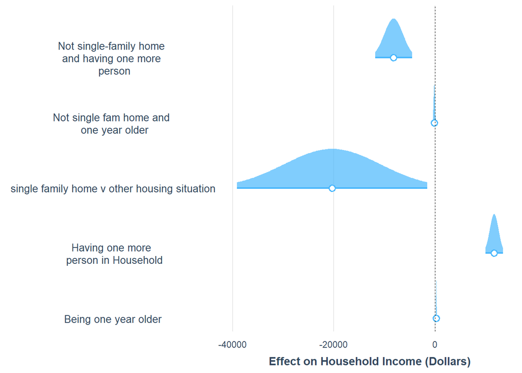

```r
coeff_interact <- c( "Being one year older" = "AGEP",
                 "Having one more \n person in Household" = "NP",
                 "single family home v other housing situation" = "bld_typenot_1_fam_home",
                 "Not single fam home and \n one year older" = "bld_typenot_1_fam_home:AGEP",
                 "Not single-family home \nand having one more \n person" = "bld_typenot_1_fam_home:NP")

plot_coefs(model_3.1,
           coefs = coeff_interact,
           plot.distributions = TRUE,
           rescale.distributions = TRUE) +
  scale_x_continuous(name = "Effect on Household Income (Dollars)")
```

### Plot Model

```r
model_3.1_plot <- interact_plot(model_3.1, pred = NP, modx = bld_type, interval = TRUE) +
  scale_y_continuous(name = " Household Income, In Thousands",
                     limits = c(0, 300000),
                     breaks = breaks <- seq(0, 300000, by = 50000),
                     labels = paste("$",
                                    prettyNum(breaks/1000, big.mark = "'"),
                                    sep = ""))

 scale_x_continuous(name = "Number of People in House",
                     breaks = seq(0, 13, by = 1))
```

```
## <ScaleContinuousPosition>
##  Range:
##  Limits:    0 --    1
```

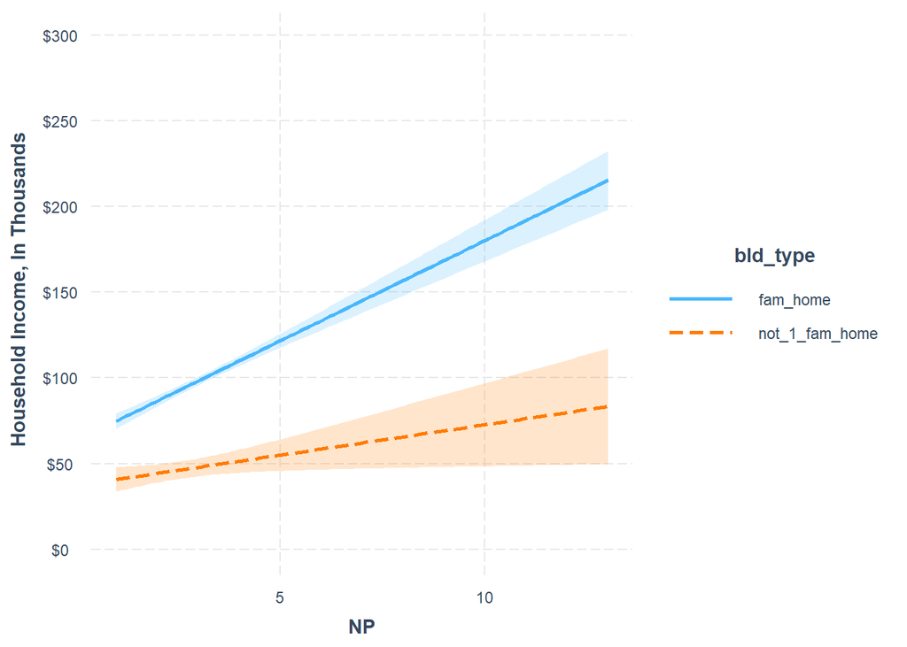

```r
model_3.1_plot
```

## **MOD4:** Household Income by Person

### Create Household Income Per Person

```r
assignment5_vars_manip <- assignment5_vars %>%
  mutate(income_per_person = HINCP/NP) %>%

dplyr::select(income_per_person, race_ethn, RAC1P_label, HISP_label, JWMNP_binned, NP, PUMA, when_built, AGEP, bld_type, PINCP, BLD_label)
```

```r
model_4 <- lm(income_per_person ~ bld_type + NP + AGEP, data =assignment5_vars_manip)
summary(model_4)
```

```
##
## Call:
## lm(formula = income_per_person ~ bld_type + NP + AGEP, data = assignment5_vars_manip)
##
## Residuals:
##    Min     1Q Median     3Q    Max
## -53988 -18799  -6994   7043 610545
##
## Coefficients:
##                         Estimate Std. Error t value Pr(>|t|)
## (Intercept)             48611.06    1866.85  26.039  < 2e-16 ***
## bld_typenot_1_fam_home -16637.14    1240.35 -13.413  < 2e-16 ***
## NP                      -5443.77     337.51 -16.129  < 2e-16 ***
## AGEP                      140.47      23.59   5.956 2.75e-09 ***
## ---
## Signif. codes:  0 '***' 0.001 '**' 0.01 '*' 0.05 '.' 0.1 ' ' 1
##
## Residual standard error: 36420 on 5432 degrees of freedom
## Multiple R-squared:  0.1077, Adjusted R-squared:  0.1072
## F-statistic: 218.6 on 3 and 5432 DF,  p-value: < 2.2e-16
```

```r
model_4.1 <- lm(income_per_person ~ bld_type + NP + AGEP + NP:bld_type + AGEP:bld_type, data =assignment5_vars_manip)
summary(model_4.1)
```

```
##
## Call:
## lm(formula = income_per_person ~ bld_type + NP + AGEP + NP:bld_type +
##     AGEP:bld_type, data = assignment5_vars_manip)
##
## Residuals:
##    Min     1Q Median     3Q    Max
## -55167 -18468  -7021   6858 609728
##
## Coefficients:
##                              Estimate Std. Error t value Pr(>|t|)
## (Intercept)                  48972.87    2069.53  23.664  < 2e-16 ***
## bld_typenot_1_fam_home      -17475.13    4212.31  -4.149 3.40e-05 ***
## NP                           -5750.79     382.78 -15.024  < 2e-16 ***
## AGEP                           153.39      26.19   5.857 4.98e-09 ***
## bld_typenot_1_fam_home:NP     1245.75     812.62   1.533    0.125
## bld_typenot_1_fam_home:AGEP    -68.34      60.13  -1.136    0.256
## ---
## Signif. codes:  0 '***' 0.001 '**' 0.01 '*' 0.05 '.' 0.1 ' ' 1
##
## Residual standard error: 36400 on 5430 degrees of freedom
## Multiple R-squared:  0.1089, Adjusted R-squared:  0.1081
## F-statistic: 132.7 on 5 and 5430 DF,  p-value: < 2.2e-16
```

### TABLE

```r
coeff_names <- c( "Age of Person" = "AGEP",
                 "Number Of People in House" = "NP",
                 "Single Family \n Compared to Not Single Family" = "bld_typenot_1_fam_home",
                 "Interaction:\n Not Single Family Home and Age" = "bld_typenot_1_fam_home:AGEP",
                 "Interaction: \n Not Single Family Home and Number Of People in House" = "bld_typenot_1_fam_home:NP")


export_summs(model_4, model_4.1,
             error_format = "(p = {p.value})",
             error_pos = "same",
             model.names = c("Baeline model", "Interaction Model"),
             coefs = coeff_names)
```

|  | Baeline model | Interaction Model |
| --- | --- | --- |
| Age of Person | 140.47 *** (p = 0.00) | 153.39 *** (p = 0.00) |
| Number Of People in House | -5443.77 *** (p = 0.00) | -5750.79 *** (p = 0.00) |
| Single Family Compared to Not Single Family | -16637.14 *** (p = 0.00) | -17475.13 *** (p = 0.00) |
| Interaction: Not Single Family Home and Age |  | -68.34 (p = 0.26) |
| Interaction: Not Single Family Home and Number Of People in House |  | 1245.75 (p = 0.13) |
| N | 5436 | 5436 |
| R2 | 0.11 | 0.11 |
| *** p < 0.001; ** p < 0.01; * p < 0.05. |  |  |

### Plot Coef

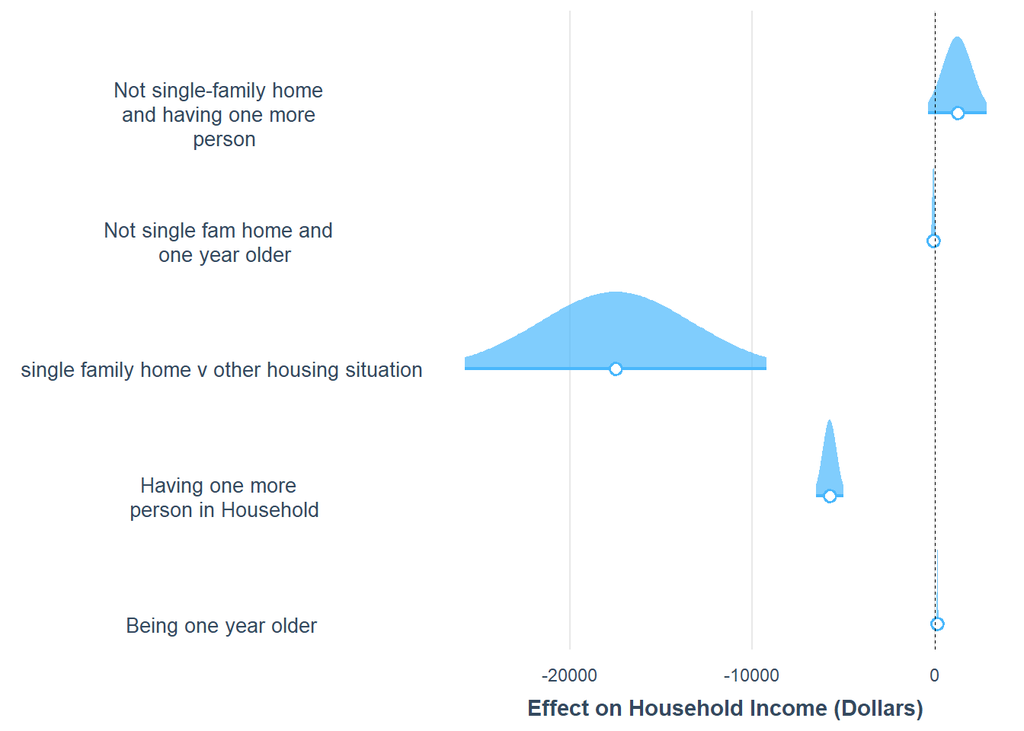

```r
coeff_interact <- c( "Being one year older" = "AGEP",
                 "Having one more \n person in Household" = "NP",
                 "single family home v other housing situation" = "bld_typenot_1_fam_home",
                 "Not single fam home and \n one year older" = "bld_typenot_1_fam_home:AGEP",
                 "Not single-family home \nand having one more \n person" = "bld_typenot_1_fam_home:NP")

plot_coefs(model_4.1,
           coefs = coeff_interact,
           plot.distributions = TRUE,
           rescale.distributions = TRUE) +
  scale_x_continuous(name = "Effect on Household Income (Dollars)")
```

### Plot Model

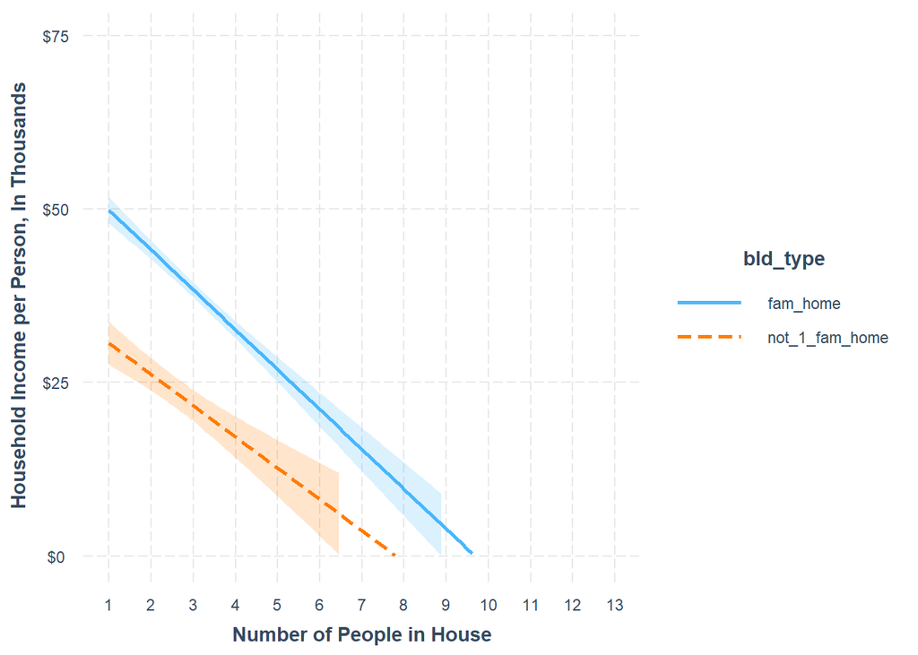

```r
model_4.1_plot <- interact_plot(model_4.1, pred = NP, modx = bld_type, interval = TRUE) +

  scale_y_continuous(name = "Household Income per Person, In Thousands",
                     limits = c(0, 75000),
                     breaks = breaks <- seq(0, 750000, by = 25000),
                     labels = paste("$",
                                    prettyNum(breaks/1000, big.mark = "'"),
                                    sep = "")) +
  scale_x_continuous(name = "Number of People in House",
                     breaks = seq(0, 13, by = 1))
model_4.1_plot
```

## **SUMMARY & ANALYSIS** Personal, Household, & Household Per Person

Below is a repeat of the three models for easier comparison.

**Question for grader** I’m wondering whether or not I should be thinking not about which graph is most interesting to me, but instead at which graph has a closer R-Squared value? If you were choosing one of these graphs for a report, would you include the first one (which has the highest R-Squared Value) or the last one (which illustrates a potential interaction effect the clearest)?

#### Personal Income (R-Squared Value .15)

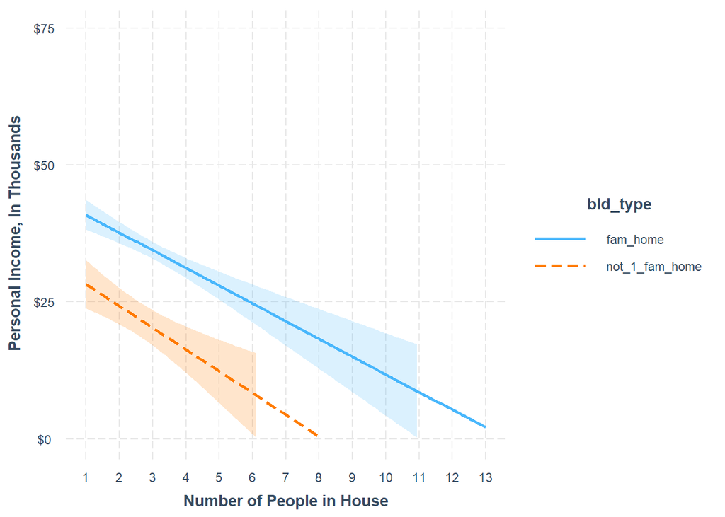

```r
model_2.1_plot
```

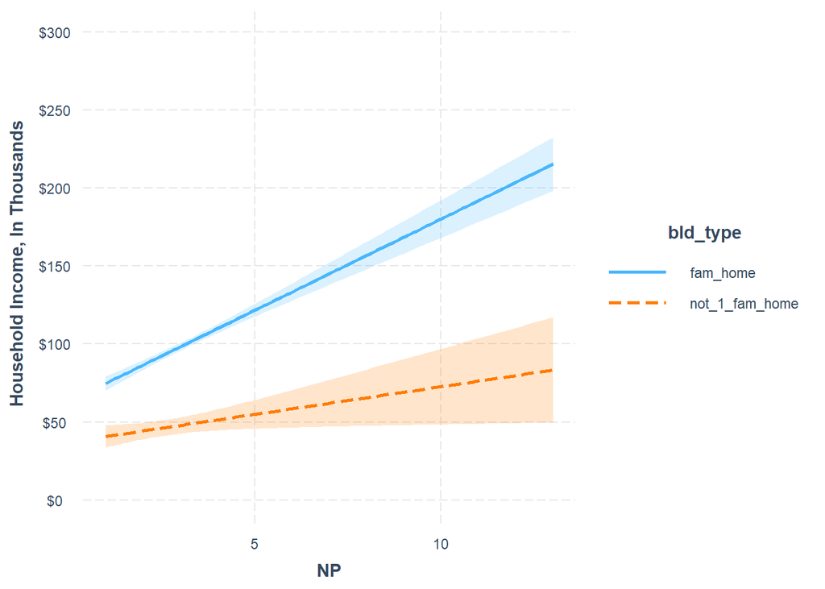

```r
model_3.1_plot
```

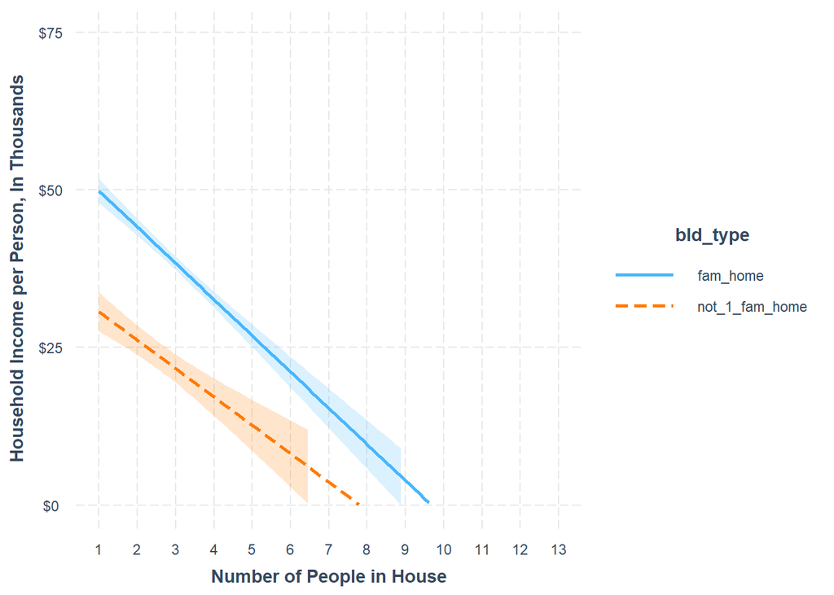

```r
model_4.1_plot
```

## **MOD5:** What type of building do you live in? (LOGISTIC REGRESSION)

**Question for Grader**: I can’t seem to get the logistic interaction plot to work. Could you glance at it? If its not super obvious, don’t worry and I’ll ask in OH this weekend.

#### Logistic Model

```r
log_reg_1 <- glm((bld_type=="fam_home") ~ assignment5_vars$when_built + assignment5_vars$race_ethn + HINCP + NP + when_built:race_ethn + when_built:race_ethn + NP:race_ethn + HINCP:race_ethn, family = binomial(link="logit"), data =assignment5_vars)

summary(log_reg_1)
```

```
##
## Call:
## glm(formula = (bld_type == "fam_home") ~ assignment5_vars$when_built +
##     assignment5_vars$race_ethn + HINCP + NP + when_built:race_ethn +
##     when_built:race_ethn + NP:race_ethn + HINCP:race_ethn, family = binomial(link = "logit"),
##     data = assignment5_vars)
##
## Deviance Residuals:
##     Min       1Q   Median       3Q      Max
## -3.7154   0.0480   0.4194   0.7108   1.9206
##
## Coefficients: (16 not defined because of singularities)
##                                                         Estimate Std. Error
## (Intercept)                                            1.538e-01  8.526e-01
## assignment5_vars$when_built1.2 40s/50s                 8.479e-01  3.006e-01
## assignment5_vars$when_built1.3 60s/70s                -6.900e-01  2.603e-01
## assignment5_vars$when_built1.4 80s/90s                -1.119e+00  2.584e-01
## assignment5_vars$when_built2000s/10s                  -4.814e-01  2.694e-01
## assignment5_vars$race_ethnBlack/AA                     1.230e+01  1.385e+03
## assignment5_vars$race_ethnNative American (Hisp)      -4.579e-01  8.818e-01
## assignment5_vars$race_ethnOther (Hisp)                -2.910e-01  8.983e-01
## assignment5_vars$race_ethnWhite (Hisp)                 6.500e-01  8.204e-01
## HINCP                                                  7.958e-06  4.580e-06
## NP                                                     4.425e-01  2.203e-01
## when_built1 pre 1940:race_ethnAsian                           NA         NA
## when_built1.2 40s/50s:race_ethnAsian                   1.377e+01  6.463e+02
## when_built1.3 60s/70s:race_ethnAsian                  -1.590e+00  5.694e-01
## when_built1.4 80s/90s:race_ethnAsian                   1.570e+00  7.016e-01
## when_built2000s/10s:race_ethnAsian                            NA         NA
## when_built1 pre 1940:race_ethnBlack/AA                        NA         NA
## when_built1.2 40s/50s:race_ethnBlack/AA                       NA         NA
## when_built1.3 60s/70s:race_ethnBlack/AA                       NA         NA
## when_built1.4 80s/90s:race_ethnBlack/AA                       NA         NA
## when_built2000s/10s:race_ethnBlack/AA                         NA         NA
## when_built1 pre 1940:race_ethnNative American (Hisp)   9.529e-01  1.184e+00
## when_built1.2 40s/50s:race_ethnNative American (Hisp)  1.486e+01  3.084e+02
## when_built1.3 60s/70s:race_ethnNative American (Hisp)  7.450e-01  3.533e-01
## when_built1.4 80s/90s:race_ethnNative American (Hisp)  1.392e-01  3.292e-01
## when_built2000s/10s:race_ethnNative American (Hisp)           NA         NA
## when_built1 pre 1940:race_ethnOther (Hisp)            -7.357e-01  7.017e-01
```

[output cut: 57 more lines]

```
## NP:race_ethnWhite (Hisp)                               -2.148  0.03170 *
## HINCP:race_ethnBlack/AA                                    NA       NA
## HINCP:race_ethnNative American (Hisp)                   1.119  0.26311
## HINCP:race_ethnOther (Hisp)                             2.075  0.03798 *
## HINCP:race_ethnWhite (Hisp)                             2.759  0.00580 **
## ---
## Signif. codes:  0 '***' 0.001 '**' 0.01 '*' 0.05 '.' 0.1 ' ' 1
##
## (Dispersion parameter for binomial family taken to be 1)
##
##     Null deviance: 5530.1  on 5435  degrees of freedom
## Residual deviance: 4560.2  on 5408  degrees of freedom
## AIC: 4616.2
##
## Number of Fisher Scoring iterations: 15
```

#### Plot Results

```r
#cat_plot(log_reg_1, pred = HINCP , modx = bld_type, interval = TRUE)
```

## **R Cheat Sheet, References & Troubleshooting**

Hello! I see this area of my assignment as predominantly a resource for myself as I learn R and as a resource to R if I ever need to return after a hiatus (and have forgotten everything I know).

Feel free to look through, but there is no need to grade anything in this section.

R Collaborative Flowchart: https://miro.com/app/board/o9J_klc5-mA=/

** Sage’s Troubleshooting Checklist**  
0. Breathe.  
1. Is everything spelled/cApiTAlized correctly?  
2. Count your parentheses(), commas, and “quotes”  
2.1 Check poles %>%, |  
3. Have you run the R chunks that are before the chunk with your error.  
5. What is the last thing you changed? Did you make sure you changed it in ALL the places it needs to be changed?  
6. Breathe. Maybe get a glass of water.  
7. Type in the ?function() into the Console  
8. Do a Google search for “R Markdown” + Your Problem  
9. Try retyping the function from scratch. 10. Try copying and pasting sections in another R Chunk –> Isolate the Problem  
11. Phone a friend.

**Common Errors:**  
-If you are having a function not found error, check whether or not you have run your libraries.  
-YAML error, check the very beginning of your code -

**If you want to see the values of a variable as they appear in your dataset** #Race  
#unique(household_data$RAC1P_label) <br/> #Hispanic <br/> #unique(household_data$HISP_label)

### References

**For General R** R is for Data Science https://r4ds.had.co.nz/index.html

Data Wrangling Cheat Sheet https://rstudio.com/wp-content/uploads/2015/02/data-wrangling-cheatsheet.pdf

*formatting* https://rstudio.com/wp-content/uploads/2015/02/rmarkdown-cheatsheet.pdf

*For GGPLOT** Top 50 Graph Types http://r-statistics.co/Top50-Ggplot2-Visualizations-MasterList-R-Code.html#Violin%20Plot

GGplot Cheat Sheet https://rstudio.com/wp-content/uploads/2015/03/ggplot2-cheatsheet.pdf

Color Pallets https://www.datanovia.com/en/blog/ggplot-colors-best-tricks-you-will-love/#predefined-ggplot-color-palettes

Look into Wes Anderson Themes, WSJ, Economist

**Number Crunching**

Another Way of Pulling Summary  
#mean(household_data$HINCP) <br/> #quantile(household_data$HINCP)  
#sd(household_data$HINCP)

Simple Explanation of Dsitributions: https://nezumisa.wordpress.com/2013/06/03/different-types-of-distributions/